# Early vs Late Respondents

Author

Astrid Castro

Published

October 24, 2025

## Introduction

The XKCD color survey had more than 200,000 participants taken over time in 2010.[^1] There was not a limit on how many questions each person got in the survey. Instead, the survey randomly generated colors to be named until the participant wanted to stop.[^2] Therefore, in our dataset, we see count responses per participant between a range of 1 to 1374. My hypothesis is: **Early respondents may have been more XKCD fans or people who like the topic of colours while later ones may have been more general internet users who saw the survey shared on blogs and social media.** This could imply that the sample composition shifted over time, potentially affecting how people labeled colors. I expect that early respondents will demonstrate greater engagement (higher number of responses per user) and more accurate or creative color naming, compared to later respondents. I am basing this on the assumption that the first people that completed the project where the interested, more familiar ones and the later people to complete it where people that tried it “for fun”.

### Indicators

To evaluate my hypothesis, I am interested in the variables `response`, `timestamp`, `user_id`, and `spam_prob`. I will take the first and last 25% of respondents to check the differences in **engagement, effort and creativity, and spam probability** between the groups.

```r
library(tidyverse)
library(gt)
library(readr)
library(dplyr)
library(lubridate)
colors <- read_csv("color_survey.csv")
```

## Let’s dive into it!

I will create a new dataframe with only the variables of interest. Then, I will use the `lubridate` library to fix the variable `timestamp`.[^3] This variable represents *Unix time* (the number of seconds since January 1, 1970). And since I want to use this variable to split the data into the two groups I will be comparing, I need to have a more readable information for it. Therefore, I will add a new column to our smaller dataset using the `as_datetime` argument. This new column will provide me the `timestamp` information in *2010-03-11 14:54:29 UTC* format.

```r
colors_sm <- colors %>%
  select(user_id, timestamp, response, spam_prob) %>%
  mutate(datetime = as_datetime(timestamp))
```

Let’s visualize the response count during the time frame the survey went live.

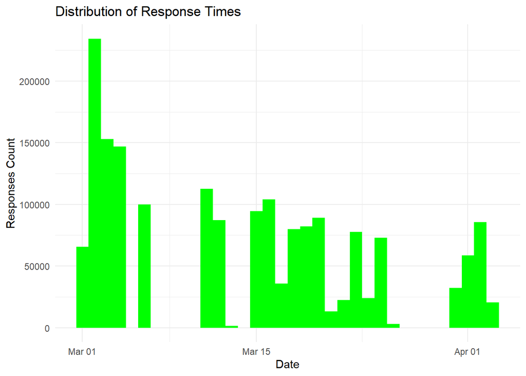

```r
ggplot(colors_sm, aes(x = datetime)) +
  geom_histogram(bins = 100,
                 binwidth = 86400,
                 fill = "green") +
  labs(title = "Distribution of Response Times",
       x = "Date",
       y = "Responses Count") +
  theme_minimal() +
  scale_fill_brewer(palette = "Dark2")
```

Given this distribution, I see there are four areas where there are no responses at all. This could be because the survey closed or due to a glitch. I do not have enough information to make a conclusion about that.

Moreover, I will split the data into two groups based on the `datetime` variable. For further information, I will make the `respondent_summary` subset that will have the response count per `user_id` and will be arranged by `datetime`. This is to later be able to compare engagement between groups.

```r
respondent_summary <- colors_sm %>%
  group_by(user_id) %>%
  summarise(response_count = n(),
            first_response_time = min(datetime, na.rm = TRUE)) %>%
  arrange(first_response_time)
```

Now let’s use the `quantile` argument to get the cutoffs at the 25th and 75th percentile. [^4]

```r
quantile(respondent_summary$first_response_time, probs = c(0.25, 0.75))
```

```
                      25%                       75%
"2010-03-03 00:47:13 UTC" "2010-03-20 08:07:01 UTC"
```

Now let’s create the two groups

```r
early_respondents <- respondent_summary %>%
  filter(first_response_time <= "2010-03-03 00:47:13 UTC") %>%
  mutate(group = "early")

late_respondents <- respondent_summary %>%
  filter(first_response_time > "2010-03-20 08:07:01 UTC") %>%
  mutate(group = "late")
```

Now I want to combine all the information I have gotten into my `respondent_summary` subset. The reason for this is because in that subset I already have a `response_count` per `user_id`, instead of duplicated `user_id`s in the `colors_sm` dataset. To do so, I will use the `bind_rows` and `left_join` functions.

```r
respondents <-
  bind_rows(early_respondents, late_respondents)

respondent_summary <- respondent_summary %>%
  left_join(respondents %>%
              select(user_id, group),
            by = "user_id")

respondent_summary <- respondent_summary %>%
  left_join(colors_sm %>%
      group_by(user_id) %>%
      summarise(avg_spam_prob = mean(spam_prob, na.rm = TRUE),
                avg_response_length = mean(nchar(response), na.rm = TRUE)),
      by = "user_id")
```

For reference, let’s do a quick summary table for `respondent_summary` but after filtering all `NA`s since I only want to include the `user_id`s that belong to our groups `early` and `late`.

```r
respondent_summary_filtered <- respondent_summary %>%
  filter(!is.na(group))

summary(respondent_summary_filtered)
```

```
    user_id       response_count    first_response_time
 Min.   :     1   Min.   :   1.00   Min.   :2010-03-01 04:45:34
 1st Qu.: 10090   1st Qu.:  10.00   1st Qu.:2010-03-01 21:52:27
 Median : 26351   Median :  17.00   Median :2010-03-03 05:24:07
 Mean   : 69032   Mean   :  22.51   Mean   :2010-03-14 04:09:19
 3rd Qu.:126710   3rd Qu.:  28.00   3rd Qu.:2010-03-25 04:02:27
 Max.   :152401   Max.   :1000.00   Max.   :2010-04-02 23:52:28
    group           avg_spam_prob       avg_response_length
 Length:37954       Min.   :0.0000742   Min.   :  1.000
 Class :character   1st Qu.:0.0036745   1st Qu.:  6.316
 Mode  :character   Median :0.0271203   Median :  7.571
                    Mean   :0.1952077   Mean   :  7.912
                    3rd Qu.:0.0757595   3rd Qu.:  9.000
                    Max.   :8.1727993   Max.   :130.200
```

## Let’s compare!

### Engagement

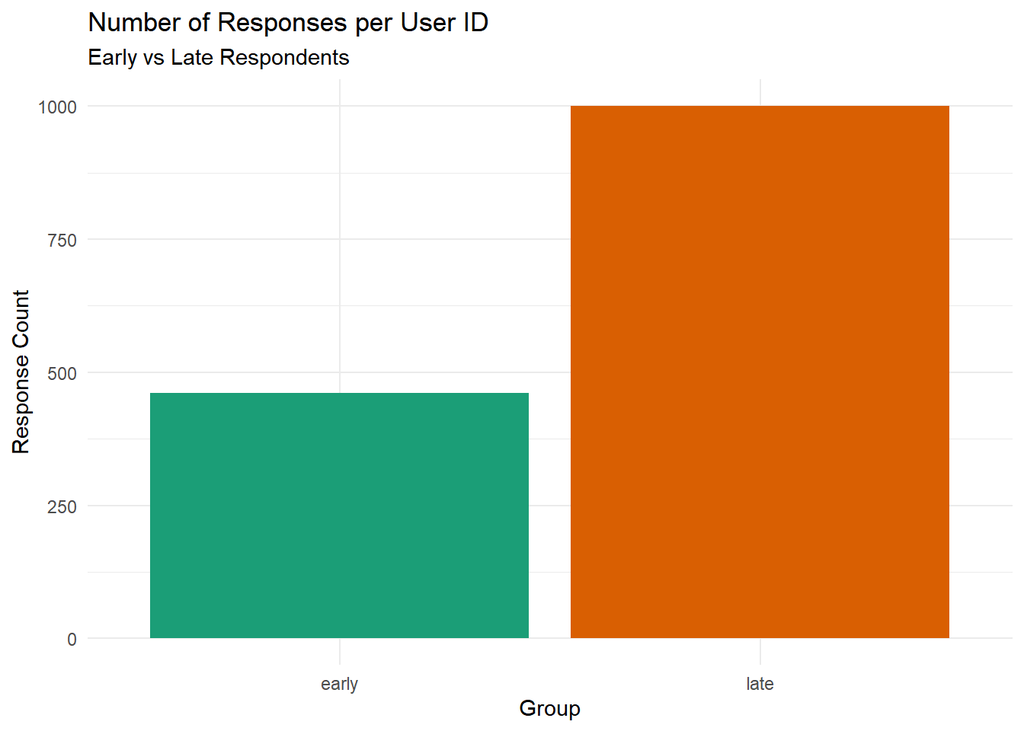

```r
ggplot(respondent_summary_filtered, aes(x = group,
                               y = response_count,
                               fill = group)) +
  geom_col(show.legend = FALSE,
           position = "dodge") +
  labs(title = "Number of Responses per User ID",
       subtitle = "Early vs Late Respondents",
       y = "Response Count",
       x = "Group") +
  theme_minimal() +
  scale_fill_brewer(palette = "Dark2")
```

### Creativity

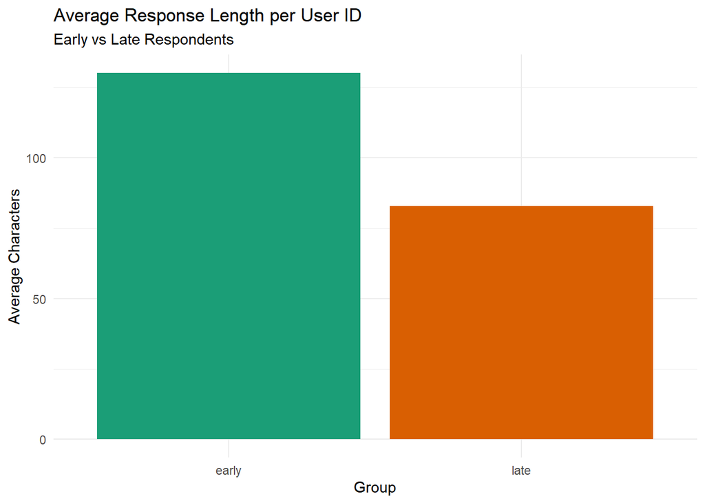

```r
ggplot(respondent_summary_filtered, aes(x = group,
                               y = avg_response_length,
                               fill = group)) +
  geom_col(show.legend = FALSE,
           position = "dodge") +
  labs(title = "Average Response Length per User ID",
  subtitle = "Early vs Late Respondents",
       y = "Average Characters",
       x = "Group") +
  theme_minimal() +
  scale_fill_brewer(palette = "Dark2")
```

### Spam Probability

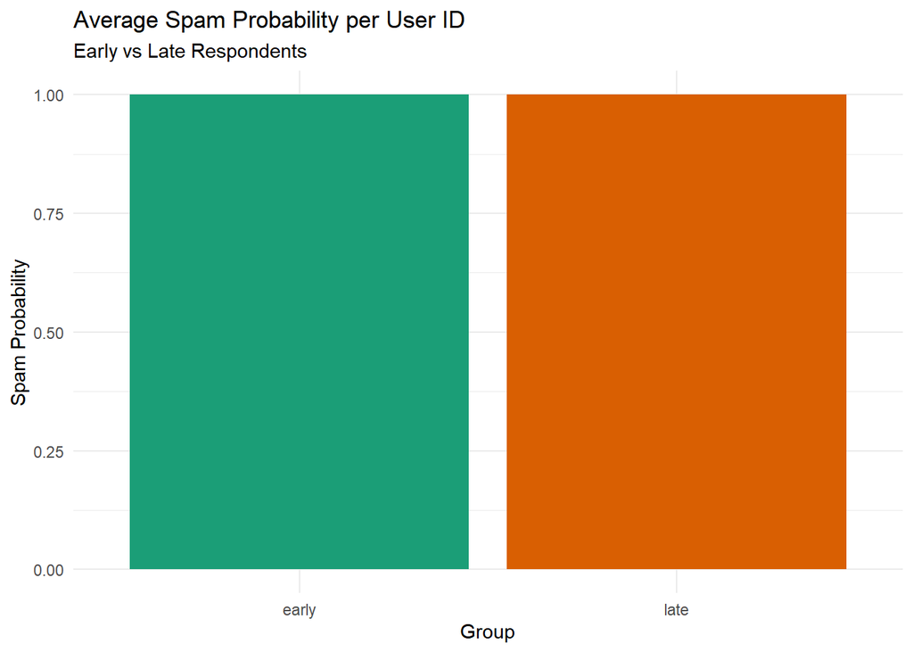

```r
respondent_summary_clean <- respondent_summary_filtered %>%
  filter(avg_spam_prob >= 0 & avg_spam_prob <= 1)

ggplot(respondent_summary_clean, aes(x = group,
                               y = avg_spam_prob,
                               fill = group)) +
  geom_col(show.legend = FALSE,
           position = "dodge") +
  labs(title = "Average Spam Probability per User ID",
  subtitle = "Early vs Late Respondents",
       y = "Spam Probability",
       x = "Group") +
  theme_minimal() +
  scale_fill_brewer(palette = "Dark2")
```

## Footnotes

[^1]: [Color Survey Results](https://blog.xkcd.com/2010/05/03/color-survey-results/)
[^2]: [Color Name Survey](https://blog.xkcd.com/2010/03/01/color-name-survey/)
[^3]: [Equitable Equations](https://equitable-equations.quarto.pub/pdar_nsp/lubridate_new.html)
[^4]: [Quantile Function in R](https://www.digitalocean.com/community/tutorials/quantile-function-in-r)